# PA2

# NOAA Storm Database:Analysis of Storm Effects on (i)Public Health and (ii)Economy for Communities

### Loading & Preprocessing Data

The following libraries are required for the following analysis

```r
    options(rpubs.upload.method = "internal")
    options(RCurlOptions = list(verbose = FALSE,
                              capath = system.file("CurlSSL", "cacert.pem",
                                                   package = "RCurl"),
                              ssl.verifypeer = FALSE))
    library(ggplot2)
    library(data.table)
    library(plyr)
```

### Data Processing

To load the data, storm data from the downloaded csv file is read. The data is then filtered to contain only the required columns of - event type - fatalities & injuries - property and crop damage & their corresponding exponentials

The resulting dataset shows events from January 1950 to November 2011.

```r
    #load the dataset from course website
    URL <- "https://d396qusza40orc.cloudfront.net/repdata%2Fdata%2FStormData.csv.bz2"
    #download.file(URL, destfile="data.csv.bz2", method="curl")

    data <- read.csv(bzfile("data.csv.bz2"))

    #subsetting the full data to only the data that is needed
    data_subset <- data[ , c("EVTYPE", "FATALITIES", "INJURIES", "PROPDMG", "PROPDMGEXP",
                           "CROPDMG", "CROPDMGEXP")]
```

### Impact on Public Health

This section of analysis examines the impact of storm on public health, namely the fatalities and injuries caused.

```r
    healthCost <- function(fieldName, top = 10, dataset = data_subset){
        index <- which(colnames(dataset) == fieldName)
        field <- aggregate(dataset[ , index], by = list(dataset$EVTYPE), FUN="sum")
        names(field) <- c("EVTYPE", fieldName)
        field <- arrange(field, field[ ,2], decreasing = T)
        field <- within(field, EVTYPE <- factor(x = EVTYPE, levels = field$EVTYPE))
        field <- field[1:top, ]
    return(field)
    }

    fatalities <- healthCost("FATALITIES")
    injuries <- healthCost("INJURIES")
```

Plotting the impact of storm data on fatalities

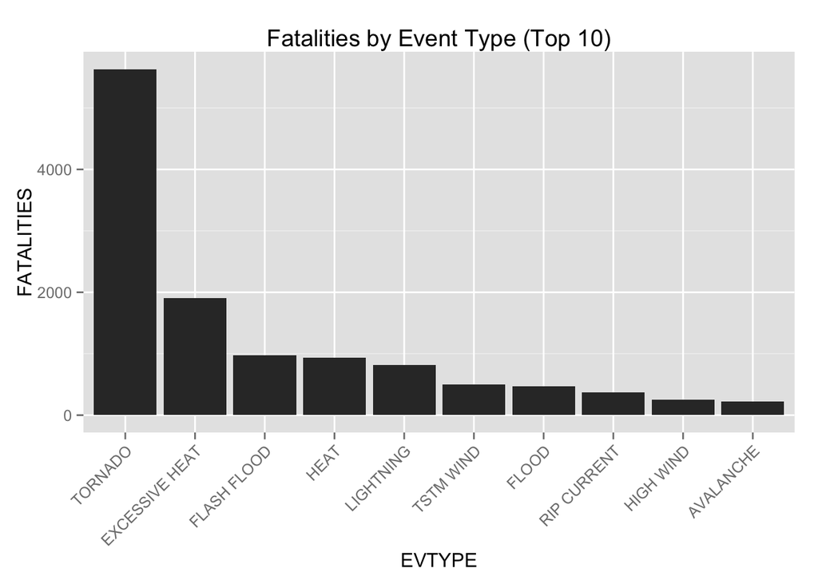

```r
   ggplot(fatalities, aes(x = EVTYPE, y = FATALITIES)) +
          geom_bar(stat ="identity") + ggtitle("Fatalities by Event Type (Top 10)") +
          theme(axis.text.x = element_text(angle = 45, hjust = 1))
```

Plotting the impact of storm data on injuiries

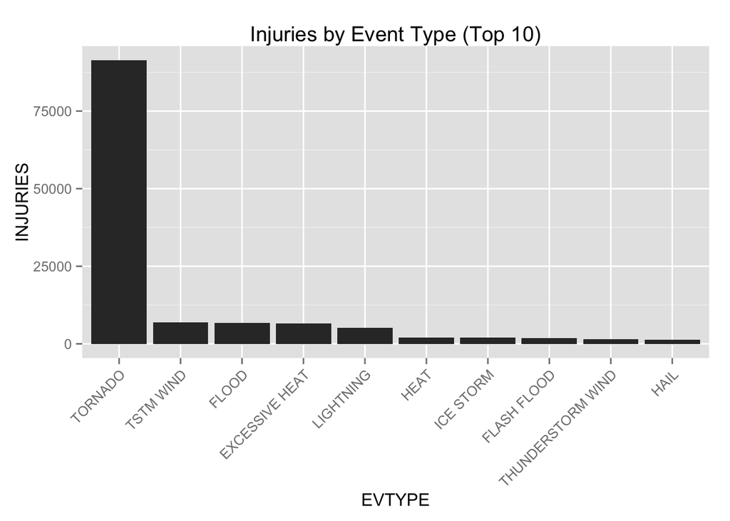

```r
    ggplot(injuries, aes(x = EVTYPE, y = INJURIES)) +
          geom_bar(stat ="identity") + ggtitle("Injuries by Event Type (Top 10)") +
          theme(axis.text.x = element_text(angle = 45, hjust = 1))
```

### Section 2 : Impact on Economy (Property and Crop Damages)

According to code book (STORM EVENTS), columns *“PROPDMGEXP”* and *“CROPDMGEXP”* are exponentials to the amount of damage done where we have Hundred (H), Thousand (K), Million (M) and Billion (B).

```r
    #subset all non-zeros in either property or crop damages; remove health fields too
    economicData <- subset(data_subset, !(PROPDMG==0 & CROPDMG==0),
                           select = -c(FATALITIES,INJURIES))
```

The **R** function *economicCost* takes in the *ecnomomicData* dataset, calculates the actual cost of damages done and returns the top 10 event types that caused the most economic damage.

```r
    economicCost <- function(category, d1 = economicData){

        i <- which(colnames(d1) == category) + 1

        d1[, i] <- toupper(as.character(d1[, i]))

        #replace the exponents with actual values
        d1[d1[, i] == "B", i] <- "1000000000"
        d1[d1[, i] == "M", i] <- "1000000"
        d1[d1[, i] == "K", i] <- "1000"
        d1[d1[, i] == "H", i] <- "100"
        d1[d1[, i] == "", i] <- "1"

        #multiply the field values by exponents to get actual damage costs
        d1[, i] <- as.numeric(d1[, i])
        cost <- d1[ ,i-1] * d1[ ,i]
        d1 <- cbind(d1, cost)

        #summarise actual damage costs by event type ; arrange and show top 10
        data <- aggregate(d1$cost, by = list(d1$EVTYPE), FUN="sum")
        data <- arrange(data, data[ ,2], decreasing = TRUE)
        data <- data[1:10, ]
        names(data) <- c("EVTYPE", "cost")
        return(data)
    }

    propCost <- economicCost("PROPDMG")
    cropCost <- economicCost("CROPDMG")
```

**Plotting the economic cost on Property** We see that FLOOD caused the most damage (US$1.4466 × 10<sup>11</sup>).

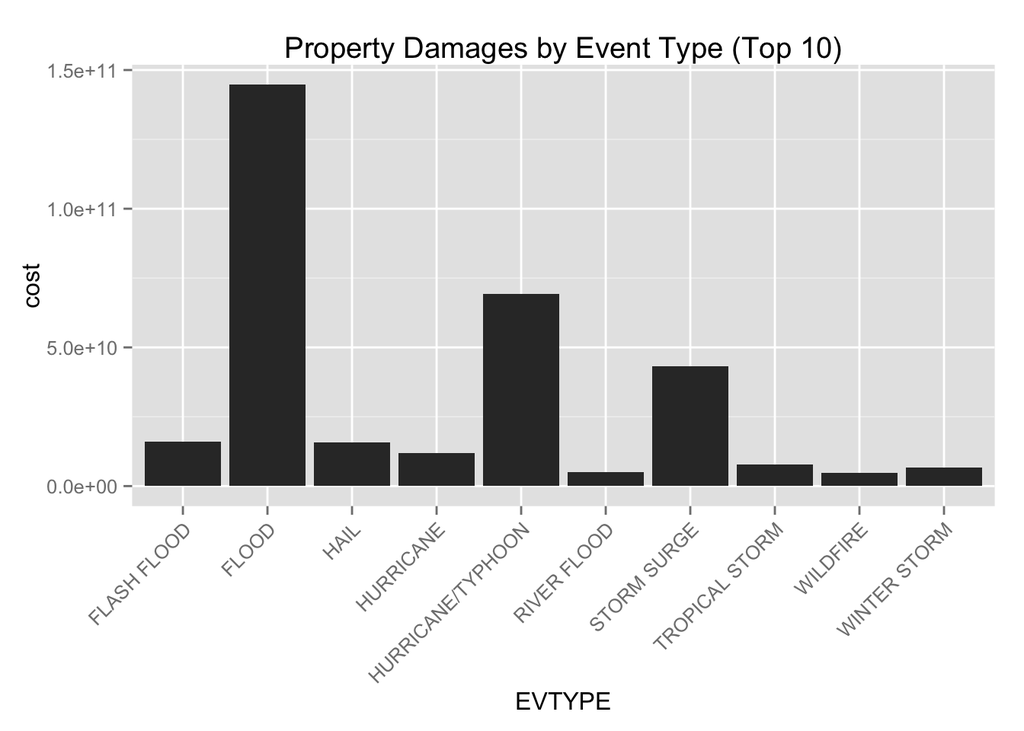

```r
    ggplot(propCost, aes(x = EVTYPE, y = cost)) +
           geom_bar(stat ="identity") +
           ggtitle("Property Damages by Event Type (Top 10)") +
           theme(axis.text.x = element_text(angle = 45, hjust = 1))
```

**Plotting the economic cost on Crop.** We see that DROUGHT caused the most damage (US$1.3973 × 10<sup>10</sup>).

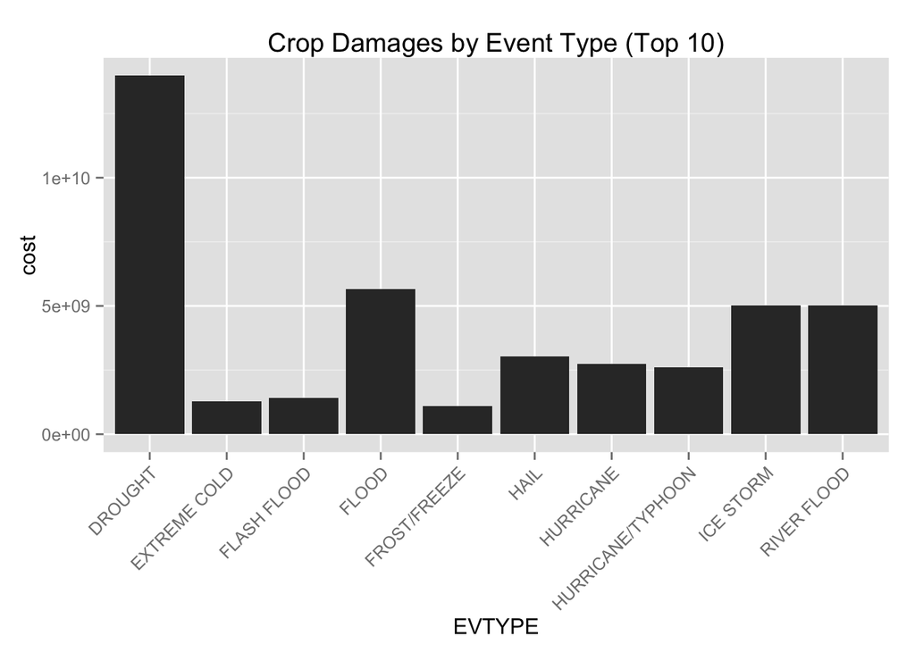

```r
      ggplot(cropCost, aes(x = EVTYPE, y = cost)) +
              geom_bar(stat ="identity") +
              ggtitle("Crop Damages by Event Type (Top 10)") +
              theme(axis.text.x = element_text(angle = 45, hjust = 1))
```